# Bridge Analysis

DX Analytics https://dxan.co.uk

20 January 2021

> Use case of bridge data analysis: Part I Interactive Data Visualisation

# 1 Data overview

Data are in a nested format: 120 recorded items per bridge per state, repeated annually in 2010 - 2018.

- **665063** structures
- **52** US states
- **5492796** structure-year records processed

## 1.1 Bridge map

[interactive chart not shown]

## 1.2 Number of structures

- Bars = Total counts across 9 years.
  - Across 9 years, how many unique structures have been recorded?
- Dots = Averaged yearly count across 9 years.
  - In each year, X number of bridges were recorded, what is the average of X in 9 years?
- Recording error in any state? Which ones?
  - Bars should be fairly close to Dots so that recording error is minor (e.g. entry error of bridge code).
  - A clear gap between bars and dots indicate a clear recording error, either at primary data collection stage or at data integration stage.
  - **Highlighted states**: Illinois, Pennsylvania, Michigan, South Carolina, Arizona.

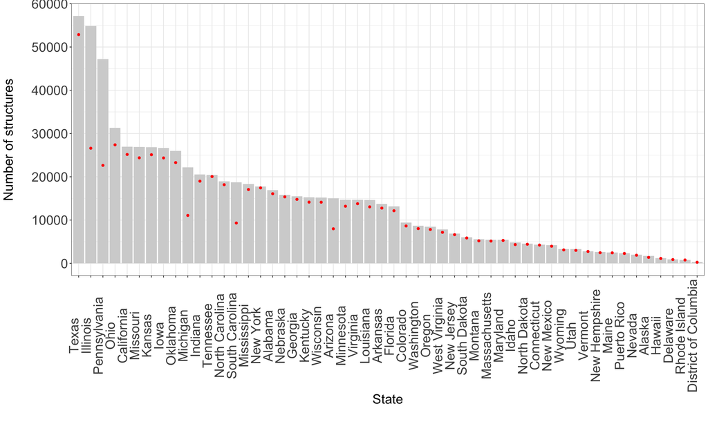

## 1.3 The top 10 states with the most structures

```
## # A tibble: 10 x 3
##    STATE_CODE_001   cnt pct
##    <fct>          <int> <chr>
##  1 Texas          57177 8%
##  2 Illinois       54877 8%
##  3 Pennsylvania   47185 6%
##  4 Ohio           31324 4%
##  5 California     26973 4%
##  6 Missouri       26887 4%
##  7 Kansas         26821 4%
##  8 Iowa           26657 4%
##  9 Oklahoma       26008 4%
## 10 Michigan       22198 3%
```

## 1.4 Number of structures over time

- Number of bridges with data in both **2010** and **2018**

```
## [1] "Count=476879 (72%)"
```

- More details

[figure not shown]

[interactive chart not shown]

# 2 Outcomes

## 2.1 Cost

- Dropdown menu to select **Bridge/Roadway/Total** cost
- Sum across all bridges within each state for each year
- One data point = one state-year record

### All states

[figure not shown]

[interactive chart not shown]

### Select states: highly variable annual cost

- List of such states is selected by the year-by-year cost variation.
- Variation = inter-quartile-range (IQR) of natural cost scale (summed over all bridges) across years.
- Cost trajectory is plotted using a log10-scale of the **total** cost for the select states.
- Solid triangle = median across these 10 selected states.

[figure not shown]

[interactive chart not shown]

### All states: by general condition

- General condition computed as the minimum of deck, superstructure, substructure, culverts condition (items 58, 59, 60, 62).
- Grouped into Poor (<=4), Fair (5-6), Good (>=7)
- Cost trajectory is plotted using a log10-scale of the **median** cost of all structures across all states in each condition bucket.
- Solid triangle = median across all conditions.

[figure not shown]

[interactive chart not shown]

### All states: by scour condition

- Grouped code: 0-3 (Closed/critical), 4-7,U (Stable), 8-9,T (Good).
- NA = not recorded
- Cost trajectory is plotted using a log10-scale of the **median** cost of all structures across all states in each condition bucket.
- Solid triangle = median across all scour conditions.

[figure not shown]

[interactive chart not shown]

## 2.2 Condition: General

- Original codes = 0 (bad) - 9 (excellent)
- Grouped codes: Poor (0-4), Fair (5-6), Good (7-9)
- General condition is computed as the minimum of deck, superstructure, substructure, culverts condition (items 58, 59, 60, 62). Grouped into Poor (<=4), Fair (5-6), Good (>=7)
- Y-axis = percentage of structures across all states in each year (stratified by respective condition)
- Unless otherwise stated, NA = not recorded/not applicable
- Dropdown menu to select states

### General

[figure not shown]

[interactive chart not shown]

### DECK

[figure not shown]

[interactive chart not shown]

### Superstructure

[figure not shown]

[interactive chart not shown]

### Substructure

[figure not shown]

[interactive chart not shown]

### Channel

[figure not shown]

[interactive chart not shown]

### Culvert

[figure not shown]

[interactive chart not shown]

## 2.3 Condition: Scour

- Original code: 0 (structure closed) - 9 (excellent condition), N, T, U
- Grouped code: 0-3 (Closed/critical), 4-7,U (Stable), 8-9,T (Good). NA = not recorded/not applicable
- Code N: no waterway (will be excluded in the following plots)
- Code T: tidal water cannot be inspected (manual states low risk)
- Dropdown menu to select states

[figure not shown]

[interactive chart not shown]

## 2.4 Evaluation: Detour

- Detour is evaluated in kilometers
- Solid triangle = median across all conditions
- Dropdown menu to select states

### All states

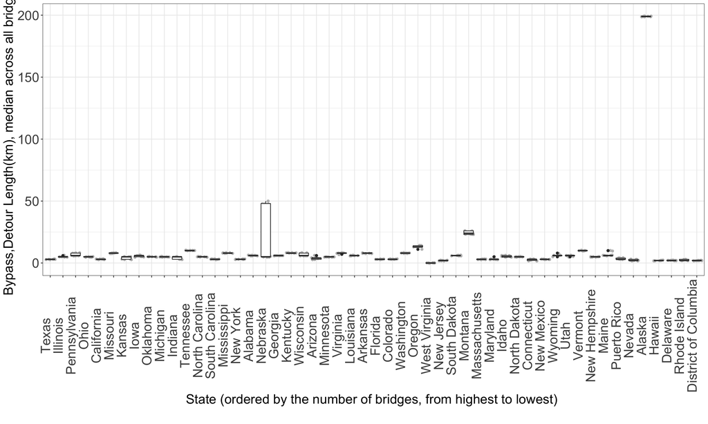

### Select states: highly variable detour by year

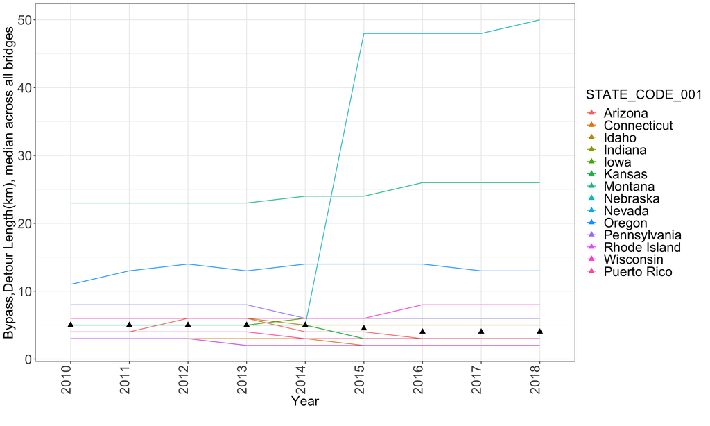

### All states: by general condition

[figure not shown]

[interactive chart not shown]

### All states: by scour condition

[figure not shown]

[interactive chart not shown]

## 2.5 Evaluation: Traffic

- Average daily traffic (ADT), recoded in millions (M)
- All plots by **general** or **scour** condition
- Dropdown menu to select states

### 2.5.1 By general condition

#### ADT (current)

- Current = at the year of inspection
- Plotted **total** ADT across all bridges

[figure not shown]

[interactive chart not shown]

#### ADT-truck (current, in %)

- Current = current percentage of the average daily traffic that is truck traffic
- Measured at the year of inspection
- Plotted **median** across all bridges

[figure not shown]

[interactive chart not shown]

#### ADT (future)

- Estimated future average daily traffic (a basis for 20-year forecast)
- Plotted **total** across all bridges

[figure not shown]

[interactive chart not shown]

### 2.5.2 By scour condition

#### ADT (current)

- Current = at the year of inspection
- Plotted **total** ADT across all bridges

[figure not shown]

[interactive chart not shown]

#### ADT-truck (current, in %)

- Current = current percentage of the average daily traffic that is truck traffic
- Measured at the year of inspection
- Plotted **median** across all bridges

[figure not shown]

[interactive chart not shown]

#### ADT (future)

- Estimated future average daily traffic (a basis for 20-year forecast)
- Plotted **total** across all bridges

[figure not shown]

[interactive chart not shown]

# 3 Relationship between outcomes

Outcomes of interest are:

1. Cost (continuous)

```
* Bridge, Roadway, Total improvement cost estimates
```

2. Condition (categorical)

```
* General
* Scour
```

3. Evaluation_Detour (continuous)
4. Evaluation_Traffic (continuous)

```
* ADT_current, ADT_truck, ADT_future
```

Correlation plots:

- Dropdown menu to select states
- Correlations are plotted for bridges with median annual values in 2010-2018
- States with co-linear outcomes are not shown (potential data recording error)
- Edge = correlation, Green = positive, Red = negative
- Non-signficant edges, with p-value (Bonferroni-corrected) > 0.05. are removed

[figure not shown]

[interactive chart not shown]

# 4 Relationship between predictors

- Distributions are summarised in a downloadable spreadsheet.
- Summaries for year 2018 are reported. 20 bridges are randomly selected in each state.
- Summaries are separated by general condition, with p-values<0.05 indicating statistically significant relationship between predictor and condition.

|  | Poor (N=84) | Fair (N=525) | Good (N=431) | Total (N=1040) | p value |
| --- | --- | --- | --- | --- | --- |
| Bypass,Detour Length(km) |  |  |  |  | 0.570 |
| - Mean (SD) | 25.5 (53.6) | 30.0 (79.5) | 38.6 (117.5) | 33.2 (95.7) |  |
| - Range | 0.0 - 199.0 | 0.0 - 999.0 | 0.0 - 999.0 | 0.0 - 999.0 |  |
| Toll status |  |  |  |  |  |
| - Toll bridge | 0 (0.0%) | 1 (0.2%) | 0 (0.0%) | 1 (0.1%) |  |
| - On toll road | 1 (1.2%) | 7 (1.3%) | 3 (0.7%) | 11 (1.1%) |  |
| - On free road | 83 (98.8%) | 517 (98.5%) | 426 (98.8%) | 1026 (98.7%) |  |
| - On interstate toll seg. | 0 (0.0%) | 0 (0.0%) | 2 (0.5%) | 2 (0.2%) |  |
| - Toll bridge non_highway | 0 (0.0%) | 0 (0.0%) | 0 (0.0%) | 0 (0.0%) |  |
| Year Built |  |  |  |  | &lt; 0.001 |

[output cut: 352 more lines]